# Lawrence

Plot Voter Registration by County (Bar Graph) (Lawrence)

Plot Voter Registration by County (Bar Graph) What variables would you use to show this? I will plot the percentages on a split bar chart, with one side representing the proportion of republican voters and the other representing democrat voters. This will be listed out by County, roughly going west to east.

What chart type (line, scatter, bar, etc) would be most effective to show this? It will be a split bar chart

Which encodings would you map to which variables? County (position) Voter Registration count (position)

What other design considerations (color, scales, titles, labels, ticks) would you need to make? If you don't know yet, that's ok, but give a best guess. We will use color to represent the parties. Red for republican and blue for democrat, as they are socially accepted conventions to represent each party. Both sides of the axis will use the same scale, going diverging directions. Titles will be ‘Voter Registration Count’ on X, ‘Counties in Washington for Y, and ‘Total Voter Registration Count in Washington Counties’, for the title of the overall chart. There will be a legend for each party stated above.

**Statement: There is a clear correlation between geography and ideology in the state of Washington. OR High population counties/central city hubs in Washington, are home to more liberal voters.**

**Source**:https://results.vote.wa.gov/results/20241105/export.html

**USE THE FOLLOWING PLOTS BELOW FOR FINAL**

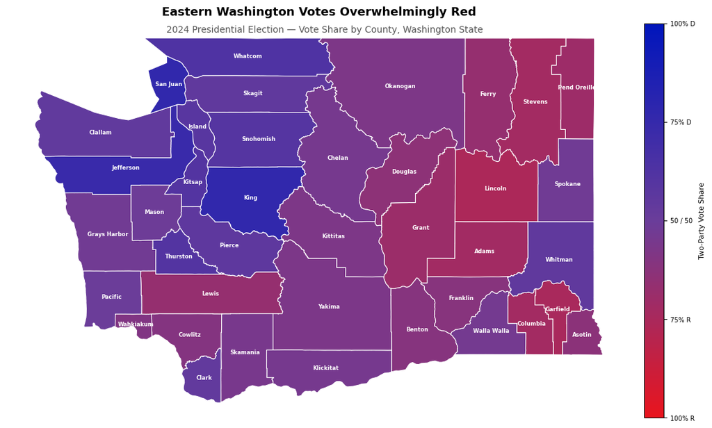

```python
import pandas as pd
import geopandas as gpd
import matplotlib.pyplot as plt
import matplotlib.colors as mcolors
import matplotlib.cm as cm
import requests, zipfile, os

DEM_COLOR = "#0015BC"
REP_COLOR = "#E9141D"

raw = pd.read_csv("20241105_allcounties.csv")
pres = raw[raw["Race"] == "United States President/Vice President"].copy()
dem = pres[pres["Party"] == "Democratic Party Nominees"][["County", "Votes"]].rename(columns={"Votes": "Dem"})
rep = pres[pres["Party"] == "Republican Party Nominees"][["County", "Votes"]].rename(columns={"Votes": "Rep"})
df = dem.merge(rep, on="County")
df["Total2P"] = df["Dem"] + df["Rep"]
df["DemShare"] = df["Dem"] / df["Total2P"]
df["County"] = df["County"].str.strip()

if not os.path.exists("counties_data/tl_2023_us_county.shp"):
    r = requests.get("https://www2.census.gov/geo/tiger/TIGER2023/COUNTY/tl_2023_us_county.zip")
    with open("us_counties.zip", "wb") as f: f.write(r.content)
    with zipfile.ZipFile("us_counties.zip", "r") as z: z.extractall("counties_data")

wa_base = gpd.read_file("counties_data/tl_2023_us_county.shp")
wa_base = wa_base[wa_base["STATEFP"] == "53"].copy()
wa_base["NAME"] = wa_base["NAME"].str.strip()
wa = wa_base.merge(df, left_on="NAME", right_on="County", how="left")

LABEL_FONT = {"fontsize": 6, "fontweight": "bold"}
cmap = mcolors.LinearSegmentedColormap.from_list("ElectionMap", [REP_COLOR, "#6a3d9a", DEM_COLOR])
norm = mcolors.TwoSlopeNorm(vmin=0.0, vcenter=0.5, vmax=1.0)

fig, ax = plt.subplots(figsize=(13, 9))
fig.patch.set_facecolor("white")
wa.plot(column="DemShare", ax=ax, cmap=cmap, norm=norm, edgecolor="white", linewidth=0.8, missing_kwds={"color": "#cccccc"})

for _, row in wa.iterrows():
    if pd.isna(row["DemShare"]): text_color = "#444444"
    else:
        rgba = cmap(norm(row["DemShare"]))
        brightness = 0.299*rgba[0] + 0.587*rgba[1] + 0.114*rgba[2]
        text_color = "white" if brightness < 0.65 else "#222222"
    ax.annotate(row["NAME"], xy=(row.geometry.centroid.x, row.geometry.centroid.y),
                ha="center", va="center", color=text_color, **LABEL_FONT)

sm = cm.ScalarMappable(cmap=cmap, norm=norm)
sm.set_array([])
cbar = fig.colorbar(sm, ax=ax, fraction=0.03, pad=0.02, ticks=[0, 0.25, 0.5, 0.75, 1.0])
cbar.ax.set_yticklabels(["100% R", "75% R", "50 / 50", "75% D", "100% D"], fontsize=7)
cbar.set_label("Two-Party Vote Share", fontsize=8, fontfamily="sans-serif")

ax.set_title("Eastern Washington Votes Overwhelmingly Red",
             fontsize=13, fontweight="bold", fontfamily="sans-serif", pad=5)
fig.text(0.5, 0.85, "2024 Presidential Election — Vote Share by County, Washington State",
         ha="center", fontsize=10, color="#555555", fontfamily="sans-serif")

ax.set_axis_off()
plt.subplots_adjust(top=0.95)
plt.savefig("wa_election_voteshare.png", dpi=180, bbox_inches="tight")
plt.show()
```

```python
import pandas as pd
import altair as alt

DEM_COLOR = "#0015BC"
REP_COLOR = "#E9141D"

df = pd.read_csv("cleaned_wa_2024_presidential.csv")

harris = df[df["Candidate"] == "Harris"][["County", "Votes", "Pct_of_Total_Votes"]].rename(
    columns={"Votes": "Harris_Votes", "Pct_of_Total_Votes": "Harris_Pct"})
trump = df[df["Candidate"] == "Trump"][["County", "Votes", "Pct_of_Total_Votes"]].rename(
    columns={"Votes": "Trump_Votes", "Pct_of_Total_Votes": "Trump_Pct"})

df_plot = harris.merge(trump, on="County")
df_plot["Winner"] = df_plot.apply(
    lambda r: "Democrat" if r["Harris_Pct"] > r["Trump_Pct"] else "Republican", axis=1
)
df_plot["Trump_Plot"] = df_plot["Trump_Pct"] * -1

# West-to-east county ordering generated with Generative AI assistance
west_to_east = [
    "Clallam", "Jefferson", "Grays Harbor", "Pacific", "Wahkiakum",
    "Whatcom", "Skagit", "Island", "San Juan", "Snohomish", "King",
    "Pierce", "Thurston", "Mason", "Kitsap", "Lewis", "Cowlitz", "Clark",
    "Skamania", "Klickitat", "Yakima", "Kittitas", "Chelan",
    "Okanogan", "Douglas", "Grant", "Benton", "Franklin", "Adams",
    "Walla Walla", "Columbia", "Garfield", "Asotin", "Whitman", "Lincoln",
    "Spokane", "Ferry", "Stevens", "Pend Oreille"
]

df_plot["County"] = pd.Categorical(df_plot["County"], categories=west_to_east, ordered=True)
df_plot = df_plot.sort_values("County").reset_index(drop=True)

dem_df = df_plot[["County", "Harris_Pct", "Winner"]].copy()
dem_df["Party"] = "Democrat"
dem_df["Pct"] = dem_df["Harris_Pct"]
dem_df["PlotPct"] = dem_df["Harris_Pct"]

rep_df = df_plot[["County", "Trump_Pct", "Winner"]].copy()
rep_df["Party"] = "Republican"
rep_df["Pct"] = rep_df["Trump_Pct"]
rep_df["PlotPct"] = rep_df["Trump_Pct"] * -1

long_df = pd.concat([
    dem_df[["County", "Party", "Pct", "PlotPct", "Winner"]],
    rep_df[["County", "Party", "Pct", "PlotPct", "Winner"]]
]).reset_index(drop=True)

dem_counties = df_plot[df_plot["Winner"] == "Democrat"][["County", "Winner"]].copy()
rep_counties = df_plot[df_plot["Winner"] == "Republican"][["County", "Winner"]].copy()

bars = alt.Chart(long_df).mark_bar(size=10).encode(
    alt.Y("County:N",
          sort=west_to_east,
          axis=alt.Axis(labels=False, ticks=False, title="Counties in Washington (West to East)")),
    alt.X("PlotPct:Q",
          title="Vote Share (%)",
          scale=alt.Scale(domain=[-85, 85]),
          axis=alt.Axis(
              values=[-80, -60, -40, -20, 0, 20, 40, 60, 80],
              labelExpr="abs(datum.value) + '%'",
              labelFontSize=9,
              gridColor="#e0e0e0"
          )),
    alt.Color("Party:N",
              scale=alt.Scale(
                  domain=["Democrat", "Republican"],
                  range=[DEM_COLOR, REP_COLOR]
              ),
              legend=alt.Legend(title="Party", labelFontSize=10, titleFontSize=11)),
    alt.Opacity("Pct:Q",
                scale=alt.Scale(domain=[20, 80], range=[0.5, 1.0]),
                legend=alt.Legend(
                    title="Vote Share Strength",
                    labelFontSize=9,
                    titleFontSize=10,
                    values=[20, 40, 60, 80],
                    labelExpr="datum.value + '%'"
                ))
).properties(width=620, height=800)

zeroline = alt.Chart(pd.DataFrame({"x": [0]})).mark_rule(
    color="black", strokeWidth=2
).encode(x="x:Q")

dem_labels = alt.Chart(dem_counties).mark_text(
    align="right", fontSize=9, color=DEM_COLOR, fontWeight="bold"
).encode(
    alt.Y("County:N", sort=west_to_east, axis=None),
    text="County:N"
).properties(width=120, height=800)

rep_labels = alt.Chart(rep_counties).mark_text(
    align="right", fontSize=9, color=REP_COLOR, fontWeight="bold"
).encode(
    alt.Y("County:N", sort=west_to_east, axis=None),
    text="County:N"
).properties(width=120, height=800)

barchart = alt.hconcat(
    (dem_labels + rep_labels),
    (bars + zeroline),
    spacing=0
).properties(
    title=alt.TitleParams(
        text="Eastern Washington Votes Overwhelmingly Republican",
        subtitle="Two-party vote share by county, west to east | Source: WA Secretary of State, Nov 2024",
        fontSize=15,
        subtitleFontSize=10,
        subtitleColor="#555555",
        anchor="middle"
    )
).configure_view(
    stroke=None
).configure_axis(
    labelFontSize=9,
    titleFontSize=11
)

barchart
```

[interactive chart not shown]

```python
import pandas as pd
import altair as alt

DEM_COLOR = "#0015BC"
REP_COLOR = "#E9141D"

raw = pd.read_csv("20241105_allcounties.csv")
pres = raw[raw["Race"] == "United States President/Vice President"].copy()

dem = pres[pres["Party"] == "Democratic Party Nominees"][["County", "Votes"]].rename(columns={"Votes": "Dem"})
rep = pres[pres["Party"] == "Republican Party Nominees"][["County", "Votes"]].rename(columns={"Votes": "Rep"})

df = dem.merge(rep, on="County")
df["Total2P"]  = df["Dem"] + df["Rep"]
df["DemShare"] = df["Dem"] / df["Total2P"] * 100
df["County"]   = df["County"].str.strip()

# AI used for data organization based on 2020 census bureau data
washington_county_population_2020 = {
    "Adams": 20613, "Asotin": 22285, "Benton": 206873,
    "Chelan": 79074, "Clallam": 77155, "Clark": 503311,
    "Columbia": 3952, "Cowlitz": 110730, "Douglas": 42938,
    "Ferry": 7178, "Franklin": 96749, "Garfield": 2286,
    "Grant": 99123, "Grays Harbor": 75636, "Island": 86857,
    "Jefferson": 32977, "King": 2269675, "Kitsap": 275611,
    "Kittitas": 44337, "Klickitat": 22735, "Lewis": 82149,
    "Lincoln": 10876, "Mason": 65726, "Okanogan": 42104,
    "Pacific": 23365, "Pend Oreille": 13401, "Pierce": 921130,
    "San Juan": 17788, "Skagit": 129523, "Skamania": 12036,
    "Snohomish": 827957, "Spokane": 539339, "Stevens": 46445,
    "Thurston": 294793, "Wahkiakum": 4422, "Walla Walla": 62584,
    "Whatcom": 226847, "Whitman": 47973, "Yakima": 256728,
}

pop_df = pd.DataFrame(list(washington_county_population_2020.items()),
                      columns=["County", "Population"])

df = df.merge(pop_df, on="County", how="left")
df["Party"] = df["DemShare"].apply(lambda x: "Democrat" if x >= 50 else "Republican")

scatter = alt.Chart(df).mark_point(size=80, opacity=0.85, filled=True).encode(
    alt.X("Population:Q",
          scale=alt.Scale(type="log"),
          axis=alt.Axis(tickCount=5, format=","),
          title="County Population — 2020 U.S. Census (log scale)"),
    alt.Y("DemShare:Q",
          scale=alt.Scale(domain=[20, 85]),
          title="Democratic Two-Party Vote Share (%)"),
    alt.Color("Party:N",
              scale=alt.Scale(
                  domain=["Democrat", "Republican"],
                  range=[DEM_COLOR, REP_COLOR]
              ),
              legend=alt.Legend(title="Winning Party")),
    alt.Shape("Party:N",
              scale=alt.Scale(
                  domain=["Democrat", "Republican"],
                  range=["circle", "triangle-up"]
              ))
)

tossup = alt.Chart(pd.DataFrame({"y": [50]})).mark_rule(
    color="#aaaaaa", strokeDash=[4, 4], strokeWidth=1
).encode(y="y:Q")

tossup_label = alt.Chart(pd.DataFrame({"y": [50.8], "x": [2000000], "text": ["50% — Toss-up"]})).mark_text(
    align="right", fontSize=10, color="#aaaaaa", fontStyle="italic"
).encode(x="x:Q", y="y:Q", text="text:N")

trend = alt.Chart(df).mark_line(
    color="#555555", strokeWidth=1.2, opacity=0.6
).transform_regression(
    "Population", "DemShare", method="log"
).encode(
    alt.X("Population:Q", scale=alt.Scale(type="log")),
    alt.Y("DemShare:Q")
)

labels = alt.Chart(df).mark_text(
    align="left", dx=7, fontSize=8, color="#333333"
).encode(
    alt.X("Population:Q", scale=alt.Scale(type="log")),
    alt.Y("DemShare:Q"),
    text="County:N"
)

chart = (tossup + tossup_label + trend + scatter + labels).properties(
    width=700,
    height=450,
    title=alt.TitleParams(
        text="Larger Counties Lean Democratic",
        subtitle="Population vs. Two-Party Vote Share by County, Washington 2024 | Source: WA Secretary of State, Nov 2024",
        fontSize=15,
        subtitleFontSize=10,
        subtitleColor="#555555"
    )
).configure_view(
    stroke=None
).configure_axis(
    labelFontSize=10,
    titleFontSize=11
)

chart
```

[interactive chart not shown]